# Springboard’s Introduction to Data Science (Capstone Project) - Predicting Semiconductor Wafer Failures by Modeling Equipment Sensor Data

John Campi

Nov. 12, 2018

Abstract

The goal of this project was to create statistical and machine learning models for equipment sensor data from a semiconductor fab to predict wafer pass/fail functionality as a means to improve fab yield. The models explored were logistic regression, modified logistic regression and random forest. The best predictive model using the fewest number of sensor features was found to be iterated logistic regression with class balanced data using a SMOTE method.

| Model | TPR | TNR | Accuracy | F1.Score |
| --- | --- | --- | --- | --- |
| logistic | 0.8630 | 0.8 | 0.8590 | 0.9197 |
| iterated logistic | 0.4795 | 1.0 | 0.5128 | 0.6481 |
| iterated logistic (SMOTE) | 0.8630 | 0.8 | 0.8590 | 0.9197 |
| random forest | 0.7808 | 0.8 | 0.7821 | 0.8702 |

**Acknowledgements**

Thank you to the SpringBoard team for providing a great course and learning framework to build off of. Special thank you to my mentor, Blaine Bateman, without whom I would not have learned so much in so little time.

# 1 Introduction

In this age of electronics, a major driving force is the supply of low cost semiconductor chips. Chip manufacturing occurs in facilities call wafer fabs in which silicon wafers up to widths of 300mm are subjected to a series of processing steps that implant, deposit and etch the microelectronic circuits onto the wafer surface in a 3-dimensional construct. Each of these process steps is performed by various tools that are fitted with sensors to measure their specific operation. Traditionally these sensor data are used by the equipment operator to detect malfunctions as close to real time as possible. If an error condition is detected the operator can quickly make adjustments or stop the process to spare corrupting the existing wafer product. Controlling costs associated with material waste is a major concern for fabs. The measure of overall wafer throughput is called the fab yield (yield) and is calculated as the ratio of the number of functional wafers output from the fab divided by the total number of wafers started. The goal of the fab is to maximize yield by reducing waste by any means. One way to do this is better utilize the equipment sensor data to identify the key instrument sensors of a semiconductor manufacturing line and model the combined alarm conditions for potential wafer failures. This capability would be sought out by any semiconductor manufacturer who wants to maximize their yield. Currently wafers are tested after specific process levels are completed. Much of the critical testing can’t be performed until very far along in the manufacturing process. Thus a failure early in the process will consume costly resources as the wafer continues onto other fabrication steps, only to be scrapped at the end. If statistical sampling is used at final test then there’s also the added risk of failing chips shipping to customers. Having the ability to catch failures during any process step minimizes the chance of failure propagation and improves isolation time of equipment issues thereby greatly improving yield and reducing costs.

# 2 Data Wrangling

## 2.1 Summary of Approach.

- Assemble csv files, update variable names and format as needed.
- Remove irrelevant variables.
- Classify all missing data as “NA”.
- Impute missing data.

## 2.2 Assemble Initial Dataset.

The [SECOM Data Set](http://archive.ics.uci.edu/ml/datasets/secom) consists of two csv files. The first is a list of pass/fail and date/time results, one entry per wafer run, and the other contains the corresponding numeric results of sensor readings from a semiconductor manufacturing line. The data files do not contain a header so variable names ‘Status’, ‘Date’, and ‘Time’ were assigned for pass = -1 / fail = +1, date and time. The ‘Status’ variable is then updated to pass = 0 / fail = +1 for convenience when fitting the data to categorical models. The remaining variables assumed default names: V1, V2, etc. Table 2.1 below shows a sampling of the initial dataset. Since the sensor variables are not named in the original dataset, and since no information is provided about the physical meaning, source or process order of each sensor’s data, there is no way to attribute any process or business meaning to the data. Therefore the analysis herein will take a “black box” approach.

Table 2.1: Sampling of the SECOM dataset.

| Status | Date | Time | V1 | V2 | V3 | V4 |
| --- | --- | --- | --- | --- | --- | --- |
| 0 | 19/07/2008 | 11:55:00 | 3030.93 | 2564.00 | 2187.733 | 1411.1265 |
| 0 | 19/07/2008 | 12:32:00 | 3095.78 | 2465.14 | 2230.422 | 1463.6606 |
| 1 | 19/07/2008 | 13:17:00 | 2932.61 | 2559.94 | 2186.411 | 1698.0172 |
| 0 | 19/07/2008 | 14:43:00 | 2988.72 | 2479.90 | 2199.033 | 909.7926 |
| 0 | 19/07/2008 | 15:22:00 | 3032.24 | 2502.87 | 2233.367 | 1326.5200 |

## 2.3 Initial Cleanup

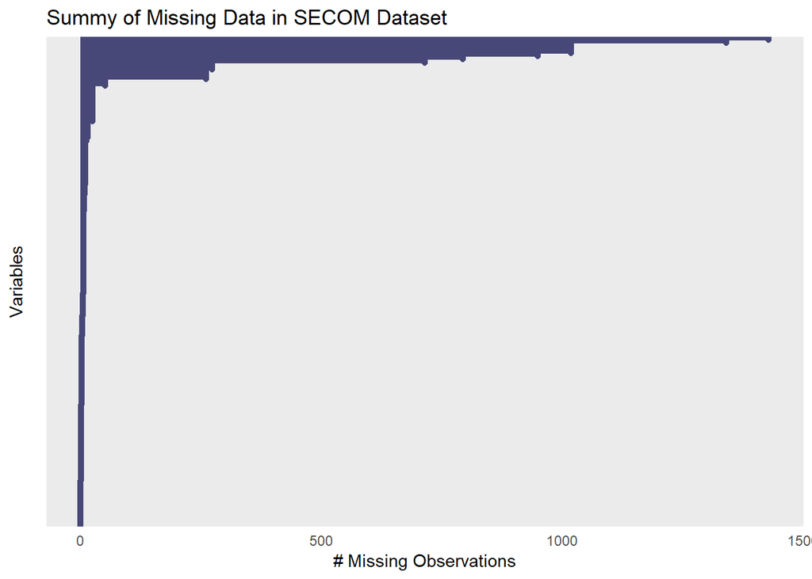

Fig. 2.1: Visualization of initial missingness.

## 2.4 Imputation

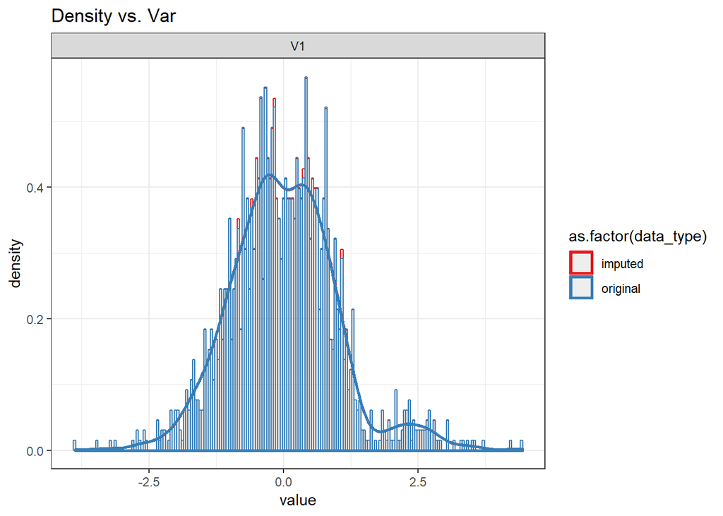

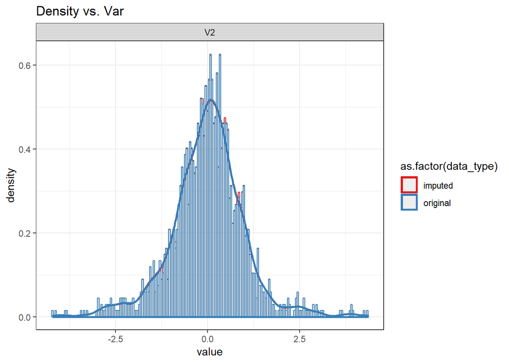

Fig. 2.2: Example distributions before and after imputation

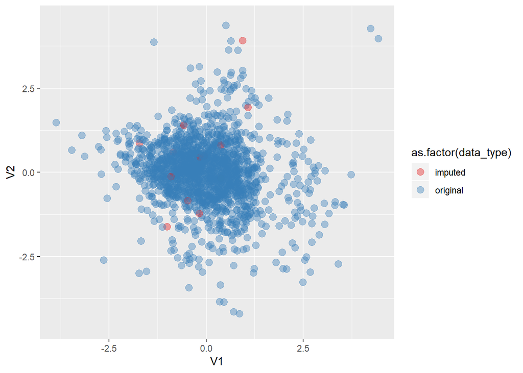

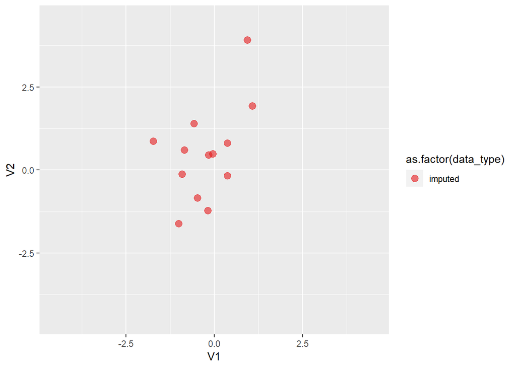

Fig. 2.3: Example scatterplot overlay of imputed and original data. Imputed data is shown standalone on the right.

Table 2.2: Summary of data wrangling.

| Metric | Initial | Final |
| --- | --- | --- |
| # of Variables | 593.00 | 417 |
| # of Observations | 1567.00 | 1567 |
| % Missings | 4.51 | 0 |

# 3 Data Exploration

## 3.1 Sensor Data Distributions

An important requirement for developing a multivariate model for this project is how well the individual sensor data distributions can be modeled by a known statistical distribution type. Ideally each variable would follow the well known normal distribution. The figure below shows an example of one variable in the SECOM dataset that is roughly normal based on visual inspect of the probability density (PDF) distribution. Included below that is its corresponding Q-Q plot, or quantile plot, which plots the measured versus theoretical quantile data. For an ideal normal distribution the fit line of a Q-Q plot would be colinear with the data and have very small residuals over the entire +3/-3 z-score range. The farther the fit line deviates from data the less confident we can be that the distribution is normal. A reasonable target is that at least 95% of the data fits the distribution which corresponds to a good fit between z = +/-1.96. Since the goal of the model in this project is to predict physical wafer failures based on production sensor data, the PDF and Q-Q plots are also shown comparing passing and failing results. Except for differences in the tails, there’s very little distinction between the distributions. Since it’s not known if the differences in the tail data is important or not, the apparent outliers will not be removed from the analysis yet. The second set of plots in Fig. 3.2 below show the data for another sensor which also follows a normal distribution, but comparison of yield results shows differences in both the peak probability and tail distribution.

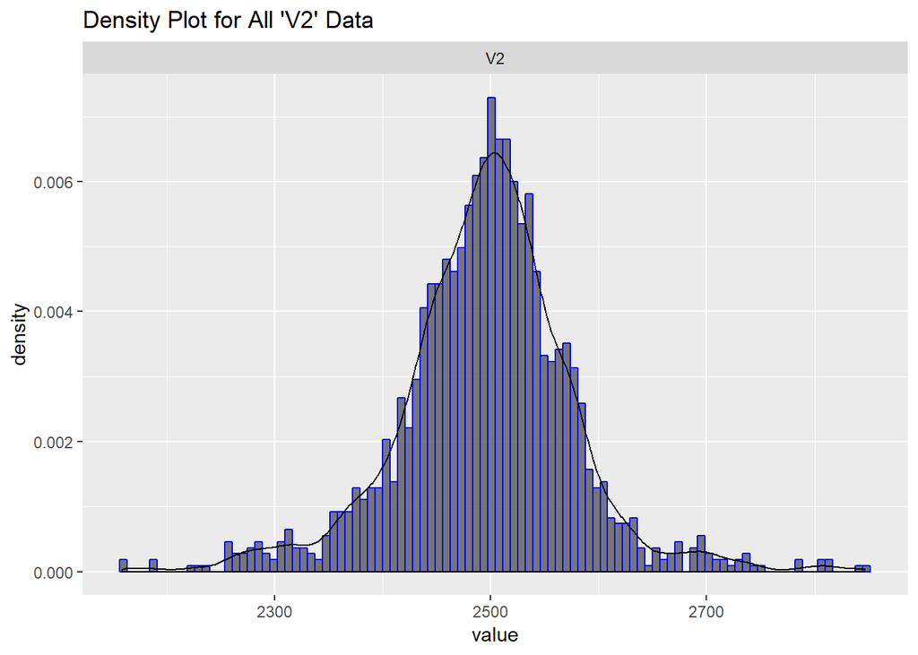

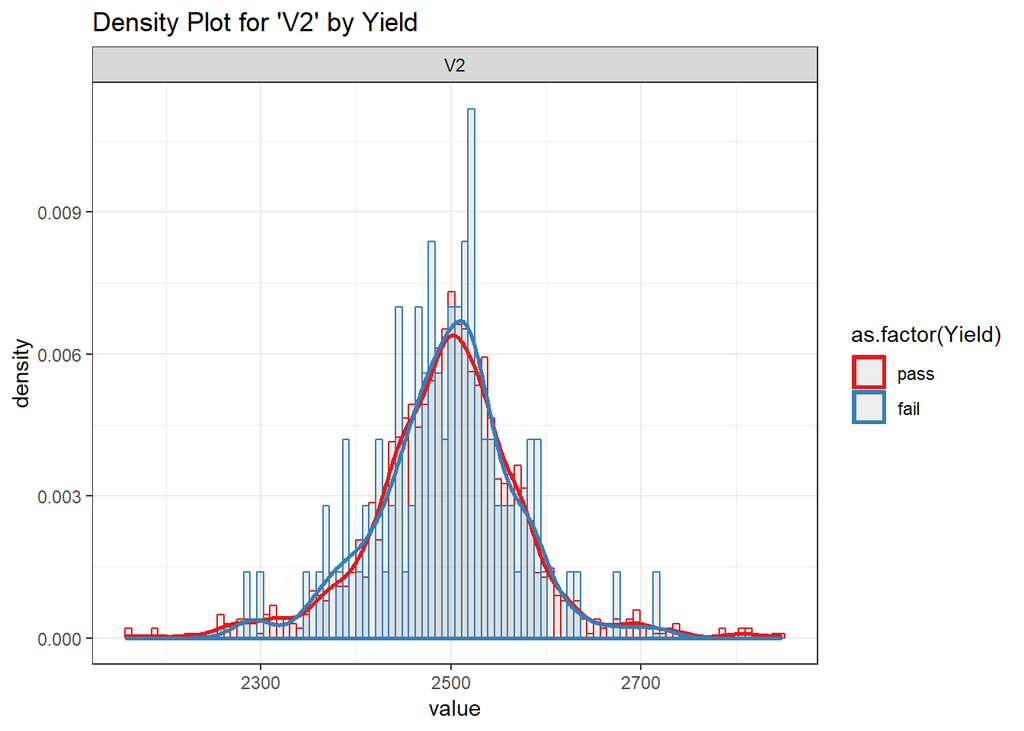

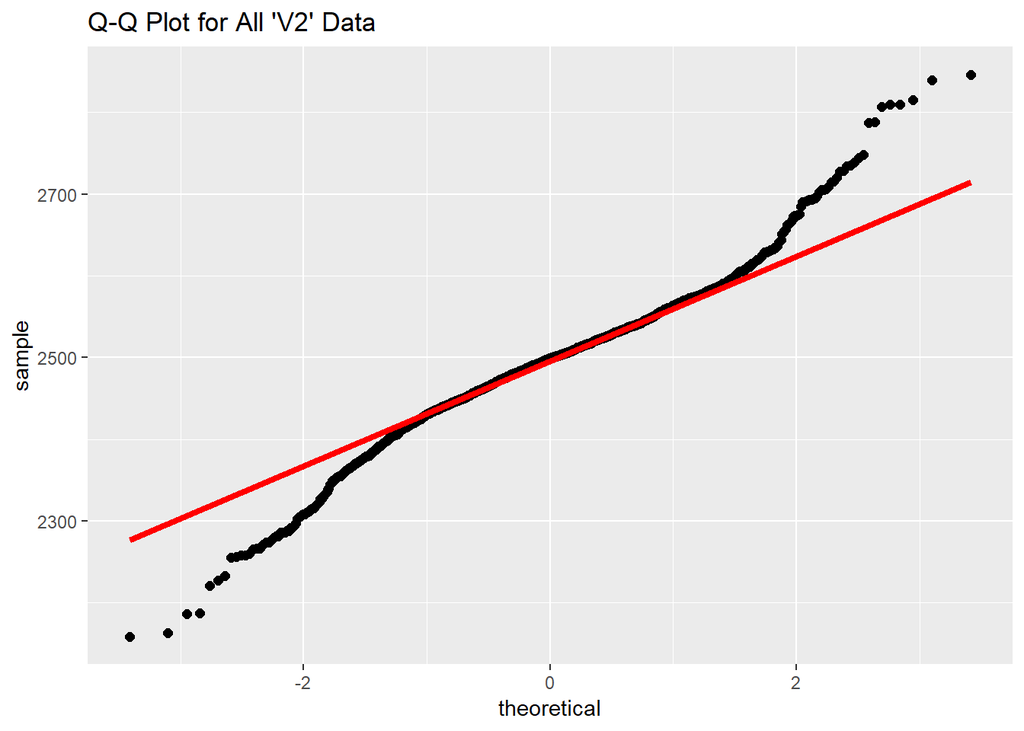

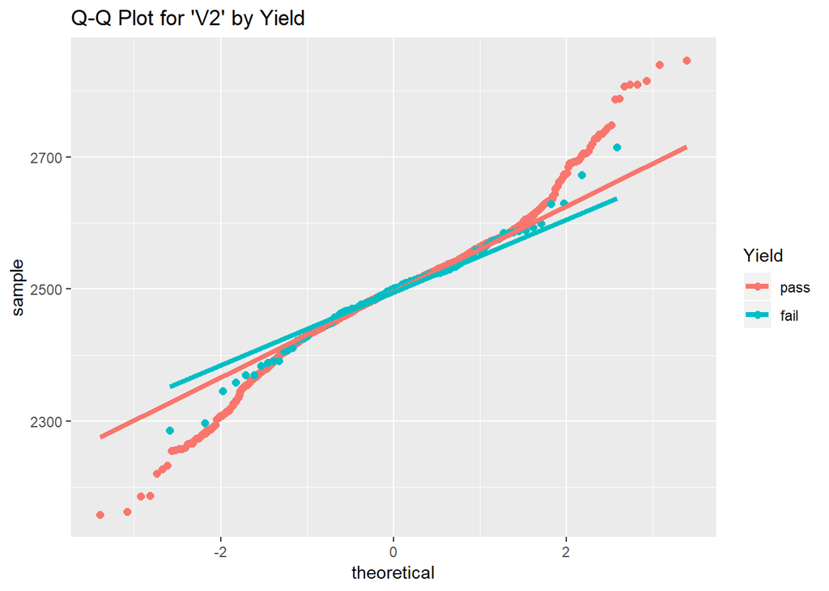

Fig. 3.1: Example of near normal distributions.

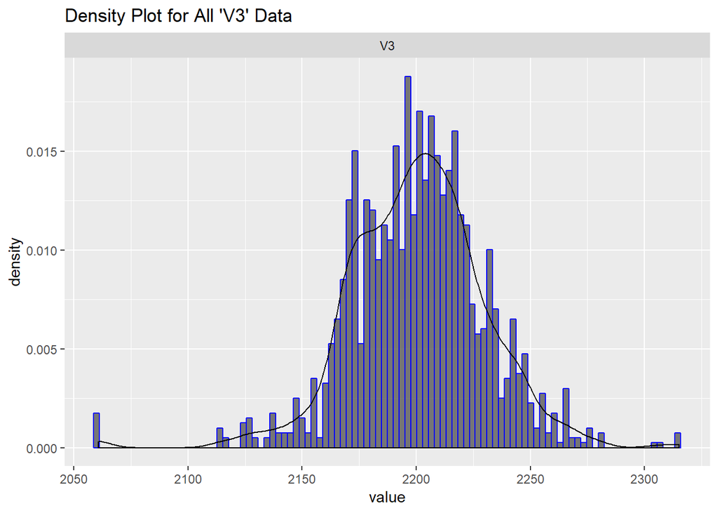

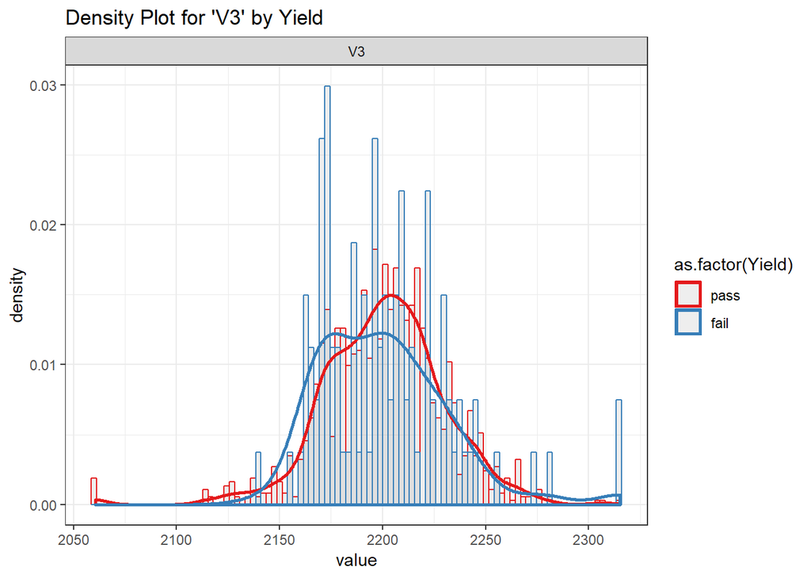

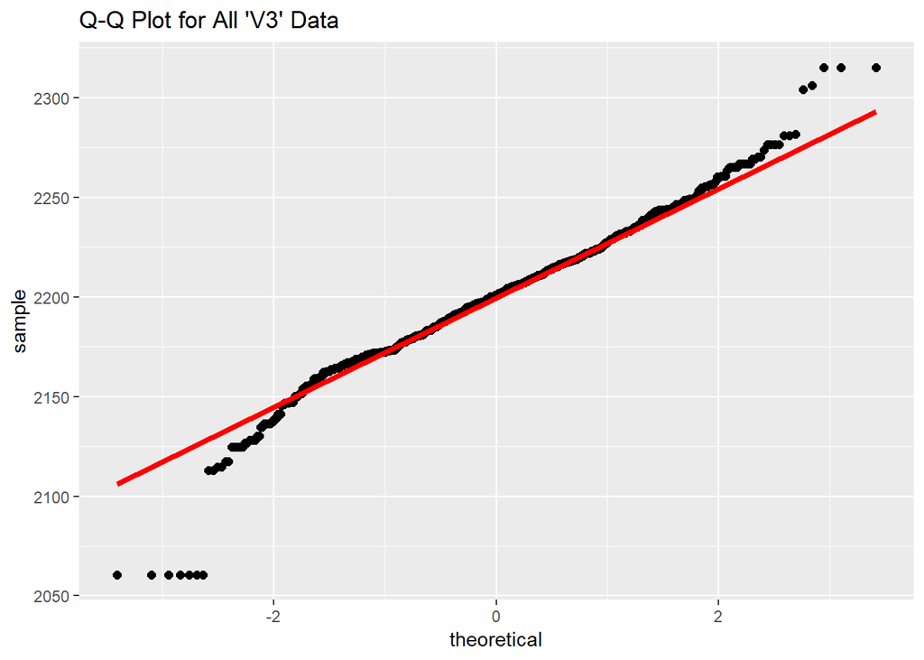

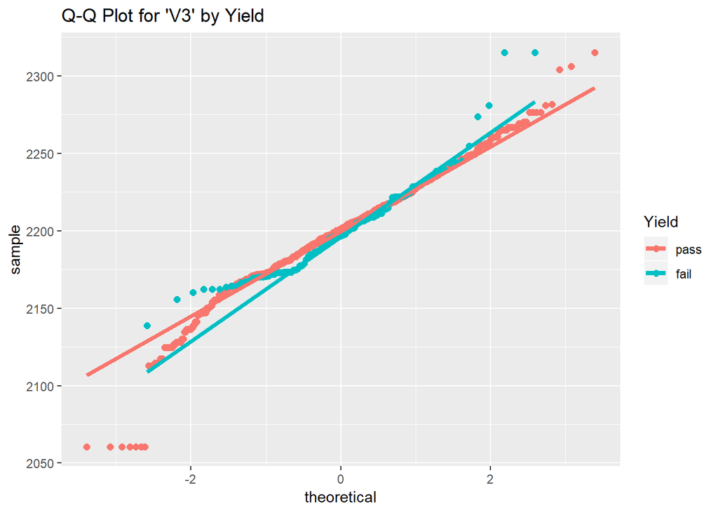

Fig. 3.2: Example of near normal distributions with yield differences.

What happens then for data that do not exhibit a normal distribution? The figure below shows the case for a right-skewed distribution at the top left with corresponding Q-Q plot below it. The longer right tail is clear in the PDF but really stands out in the Q-Q plot where the trend sharply deviates near z = +1. For distributions like this one the plan is to transform the original data into a form that is closer to normal. The plots on the right side show the result after taking the logarithm of the sensor values. The effect is seen as rebalancing the distribution, making it more symmetric about the mean. There are many non-normal distribution types available for custom fitting these data, but the approach that will be taken here will be to apply logarithmic transform, or shift + transform. The problematic situation is when the data do not follow any single distribution type but is comprised of a superposition of two or more component distributions. Fig. 3.4 below shows examples of multi-modal sensor distributions. This data could be fit with a superposition of distributions, but review of the Q-Q plots show that a normal distribution can describe the overall distribution adequately. In this project then, multi-modal distributions will be approximated by a normal or log-normal distribution as best fits the data.

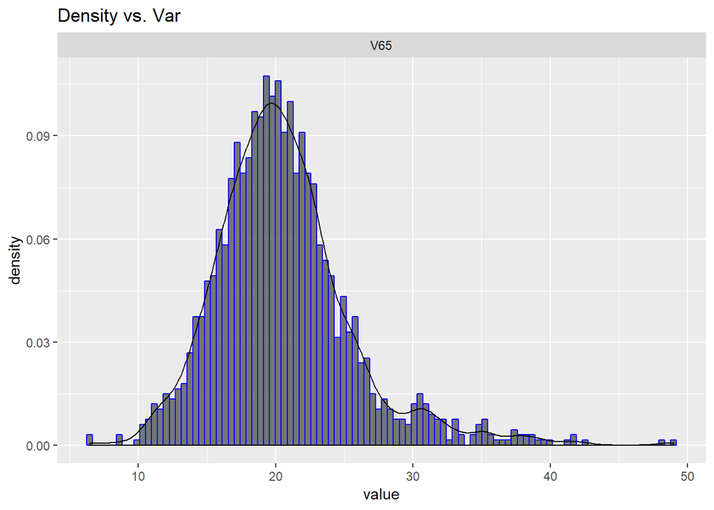

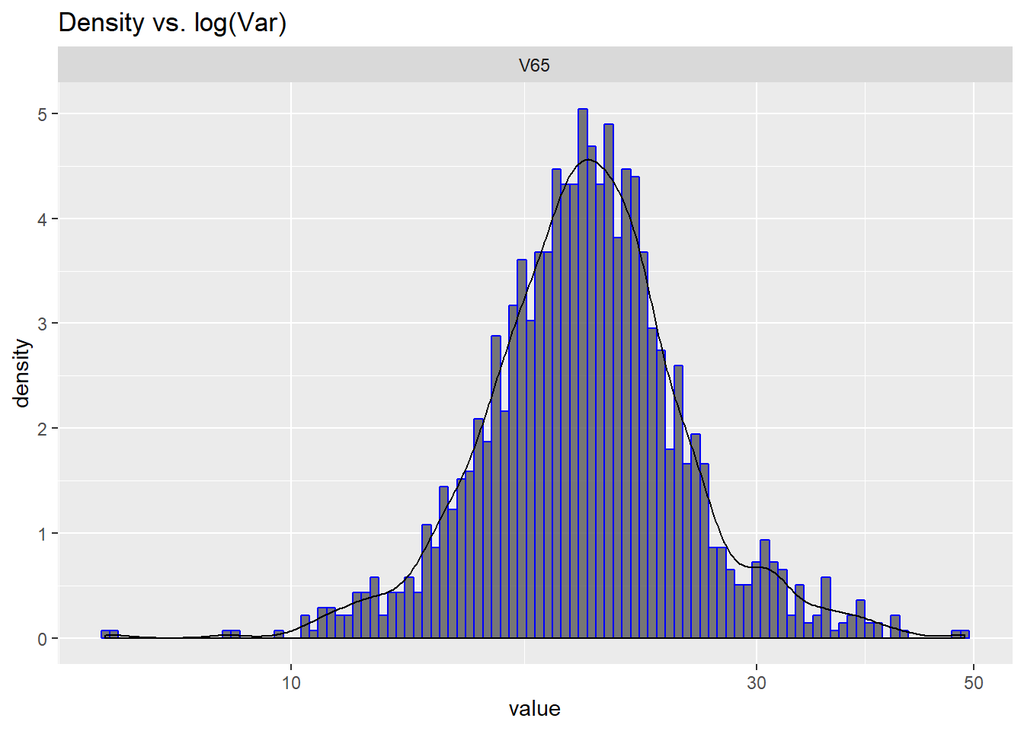

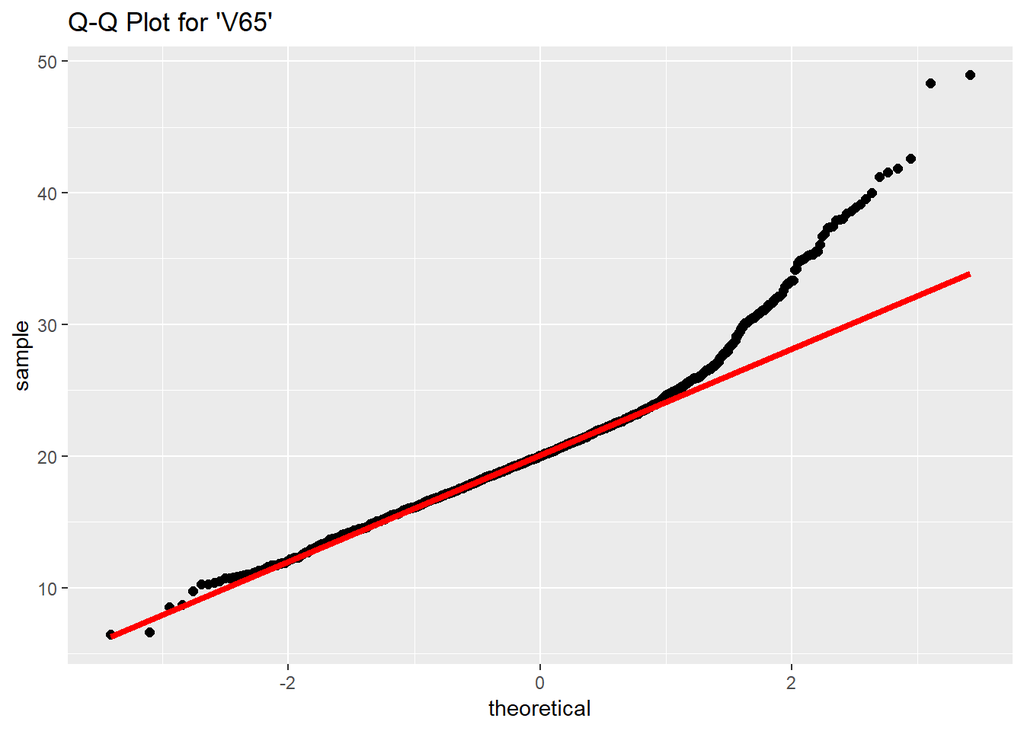

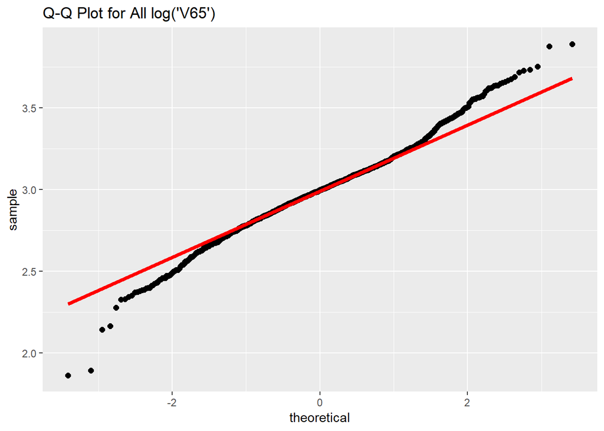

Fig. 3.3: Example skewed distribution.

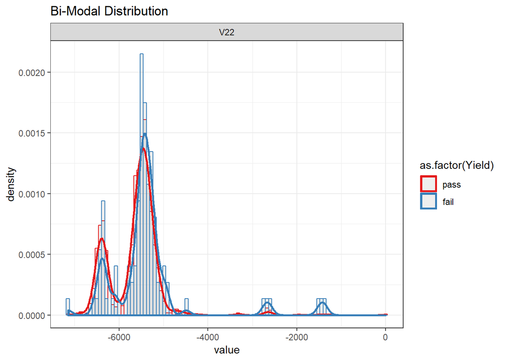

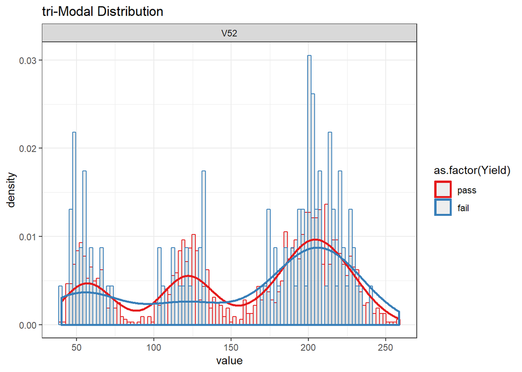

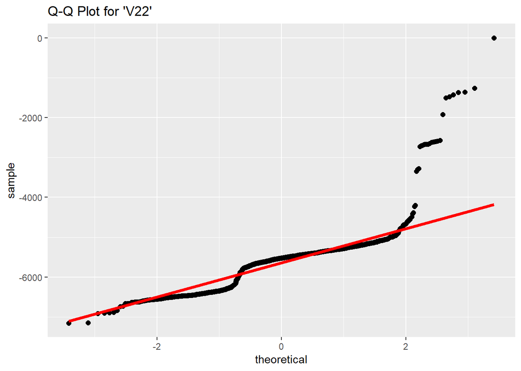

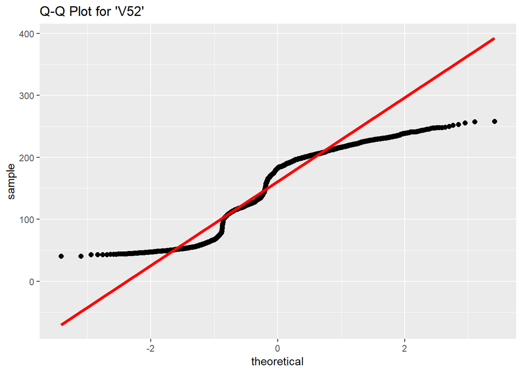

Fig. 3.4: Example multi-modal distributions.

## 3.2 Correlation Analysis

A scatter plot is good way to assess relationships between pairs of variables. The more that the data trends with a positive slope the more the two variables are correlated. On the other hand, the more the data trends with a negative slope the more the two variables are anti-correlated. When building a model with a few variables this is a convenient way to visually identify the relevant features. The example scatter plot matrix below shows the relationships between the first ten variables in the SECOM dataset plus the dependent variable ‘Status’. To quantify the relationship between two variables a correlation analysis is run and generates a correlation coefficient between -1 and +1. Correlated data obtain a coefficient > 0 up to a maximum of 1 and anti-correlated data obtain a coefficient < 0 down to a minimum of -1. Fig 3.6 shows examples of highly correlated (top), highly anti-correlated (bottom) and uncorrelated (middle) variable pairs in the SECOM dataset. Table 3.1 below that lists the same information in tabular format.

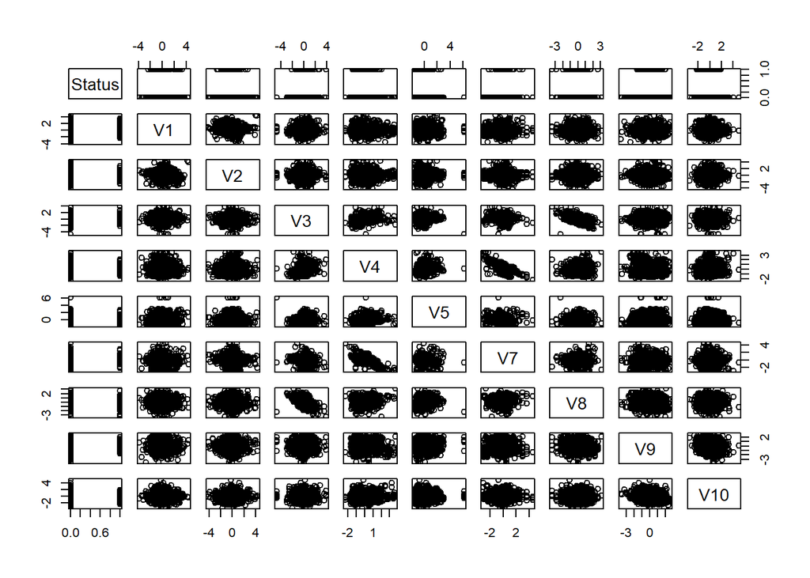

Fig. 3.5: Example scatter plot matrix.

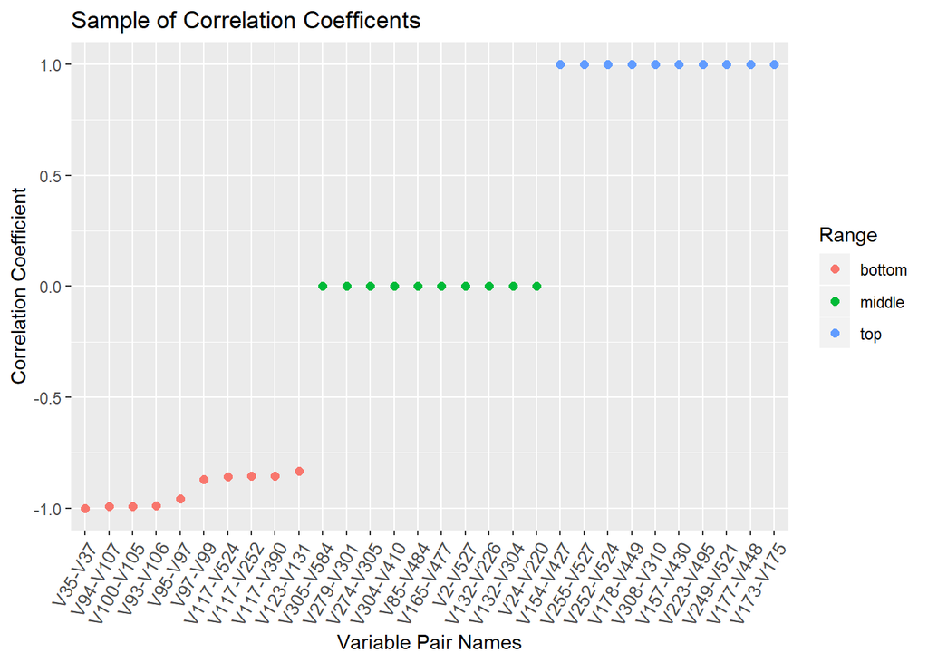

Fig. 3.6: Sample correlation coefficient ranges for the SECOM dataset.

Table 3.1: Data used for Fig. 3.6.

| Range | var1 | var2 | coeff |
| --- | --- | --- | --- |
| bottom | V35 | V37 | -0.9993 |
| bottom | V94 | V107 | -0.9916 |
| bottom | V100 | V105 | -0.9902 |
| bottom | V93 | V106 | -0.9892 |
| bottom | V95 | V97 | -0.9565 |
| bottom | V97 | V99 | -0.8713 |
| bottom | V117 | V524 | -0.8580 |
| bottom | V117 | V252 | -0.8544 |
| bottom | V117 | V390 | -0.8538 |
| bottom | V123 | V131 | -0.8321 |
| middle | V305 | V584 | 0.0000 |
| middle | V279 | V301 | 0.0000 |
| middle | V274 | V305 | 0.0000 |
| middle | V304 | V410 | 0.0000 |
| middle | V85 | V484 | 0.0000 |
| middle | V165 | V477 | 0.0000 |
| middle | V2 | V527 | 0.0000 |
| middle | V132 | V226 | 0.0000 |
| middle | V132 | V304 | 0.0000 |
| middle | V24 | V220 | 0.0000 |
| top | V154 | V427 | 0.9992 |
| top | V255 | V527 | 0.9993 |
| top | V252 | V524 | 0.9993 |
| top | V178 | V449 | 0.9995 |
| top | V308 | V310 | 0.9996 |
| top | V157 | V430 | 0.9997 |
| top | V223 | V495 | 0.9998 |
| top | V249 | V521 | 0.9998 |
| top | V177 | V448 | 0.9998 |
| top | V173 | V175 | 1.0000 |

A correlogram is another useful visualization tool for spotting trends in variable relationships. The correlogram reduces the information in the scatter plot matrix to a color-coded matrix of correlation coefficients for easy identification of trends. The relationships for the first 10 variable plus the dependent variable are shown below in Fig. 3.7. In a dataset with hundreds of variables these visual aids aren’t very useful. Fig. 3.8 below shows the case for the current SECOM dataset. The plot does show interesting clustering trends but this amount of data is too cumbersome to perform visual analyses. The approach that will be taken in this project is to select features based on their statistical significance in a given model.

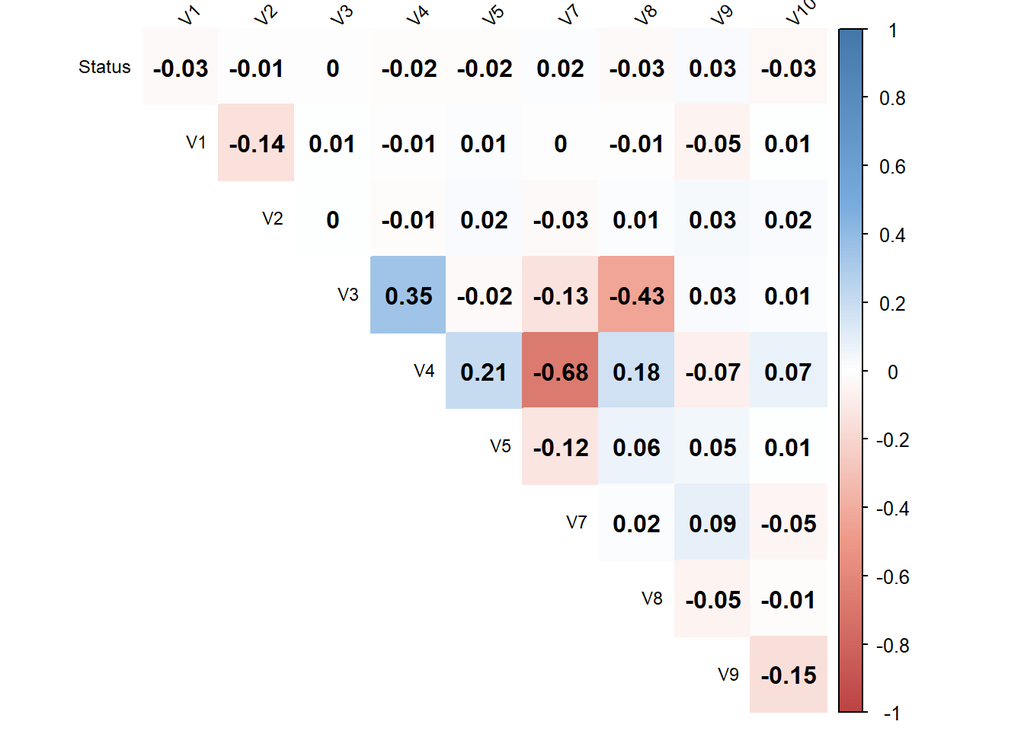

Fig. 3.7: Example correlogram plot.

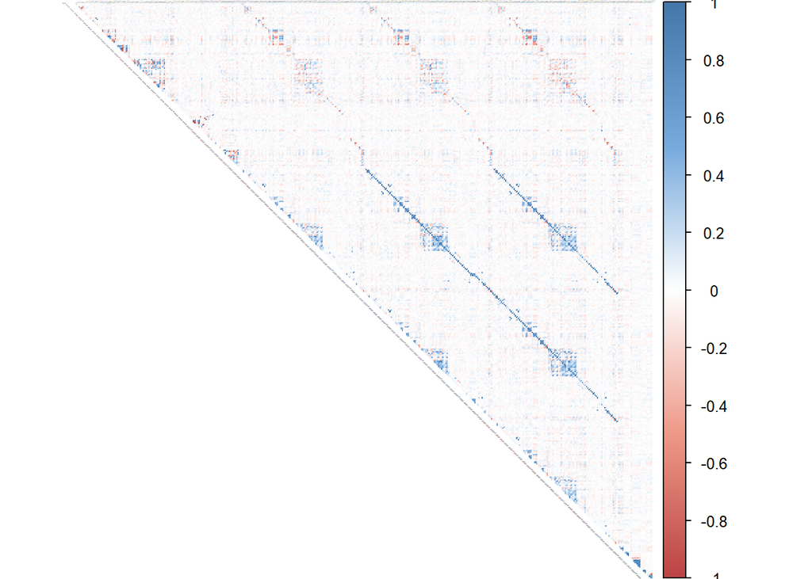

Fig. 3.8: Correlogram plot for the SECOM dataset.

While the number of cross-correlations makes visual analysis cumbersome in general, it is still interesting to review how each variable is correlated to the dependent variable, ‘Status’. Fig. 3.9 plots the SECOM variables ordered by their correlation coefficient with ‘Status’. The notable takeaway is that none of the individual variables is significantly correlated with the output response meaning that the final model should expect to retain a significant number of independent variables.

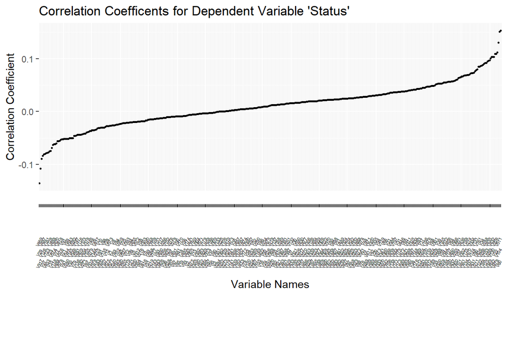

Fig. 3.9: Correlation coefficients for the dependent variable, Status.

# 4 Modeling

## 4.1 Summary of Approach.

- 3-part data split to train/tune/test (85%/10%/5%) model fits.
- Baseline logistic regression model fit.
- Iterative logistic regression model fit based on fit coefficient significance.
- Balance primary pass/fail variable (Status) classes using SMOTE.
- Repeat iterative logistic regression model fit.
- Random Forest classification model fit.

## 4.2 Data Splitting

The data approach taken here was to split the available data into 3 parts for initial model training (85%), model tuning (10%) and final test verification (5%). Table 4.1 below shows the breakdown of available data by number of observations and percentage of the total available dataset, and the number of pass/fail observations for the datasets used here. The greater than 10:1 pass:fail delta in these datasets is notable and addressed further into the analysis.

Table 4.1: Data split and Status class totals.

|  | Observations | Percent | Pass | Fail |
| --- | --- | --- | --- | --- |
| All Data | 1567 | 100.00 | 1463 | 104 |
| Train | 1332 | 85.00 | 1244 | 88 |
| Tune | 157 | 10.02 | 146 | 11 |
| Test | 78 | 4.98 | 73 | 5 |

## 4.3 Baseline Logistic Regression

### 4.3.1 Training

For this initial baseline model all available features are used for a logistic regression. The glm model was unable to converge consistently so the [**bayesglm**](https://cran.r-project.org/web/packages/arm/index.html) logistic model was chosen instead. The bayesglm model uses the Student-t distribution instead of the normal distribution which better describes the SECOM variable distributions in this work. Due to the number of available features the fitting results are lengthy so are shown in Appendix B. The model’s low AIC score of 949 indicates a parsimonious model. The confusion matrix results below show the fit accuracy = 0.9925, sensitivity (TPR) = 0.9992 and selectivity (TNR) = 0.8977 with an F1 score = 0.996. Since the purpose of the model is to accurately predict failures, TPR is a primary measure of the model capability. Accuracy and F1 score follow in assessing the overall model performance. Overall the base training model is very good.

```
## Confusion Matrix and Statistics
##
##           Reference
## Prediction    0    1
##          0 1243    9
##          1    1   79
##
##                Accuracy : 0.9925
##                  95% CI : (0.9862, 0.9964)
##     No Information Rate : 0.9339
##     P-Value [Acc > NIR] : < 2e-16
##
##                   Kappa : 0.9365
##  Mcnemar's Test P-Value : 0.02686
##
##             Sensitivity : 0.9992
##             Specificity : 0.8977
##          Pos Pred Value : 0.9928
##          Neg Pred Value : 0.9875
##              Prevalence : 0.9339
##          Detection Rate : 0.9332
##    Detection Prevalence : 0.9399
##       Balanced Accuracy : 0.9485
##
##        'Positive' Class : 0
##
```

After running the tuning data against the model the accuracy drops to 0.8917, TPR to 0.9178 and F1 score to 0.9404. Overall this is okay but TNR is very low.

```
## Confusion Matrix and Statistics
##
##           Reference
## Prediction   0   1
##          0 134   5
##          1  12   6
##
##                Accuracy : 0.8917
##                  95% CI : (0.8323, 0.9356)
##     No Information Rate : 0.9299
##     P-Value [Acc > NIR] : 0.9728
##
##                   Kappa : 0.358
##  Mcnemar's Test P-Value : 0.1456
##
##             Sensitivity : 0.9178
##             Specificity : 0.5455
##          Pos Pred Value : 0.9640
##          Neg Pred Value : 0.3333
##              Prevalence : 0.9299
##          Detection Rate : 0.8535
##    Detection Prevalence : 0.8854
##       Balanced Accuracy : 0.7316
##
##        'Positive' Class : 0
##
```

### 4.3.2 ROC Analysis

The area under the receiver operating characteristic (ROC) curve, or area under the curve (AUC), illustrates the diagnostic ability of a binary classifier model as its discrimination threshold is varied between 0 and 1. The curve is a plot of the true positive rate (TPR, sensitivity) against the false positive rate (1 - TNR, 1 - specificity) with the range of AUC between 0.5 and 1. A score of 0.5 corresponds to having little discernability or little predictability better than chance and is represented by a 45 degree line. A score of 1 corresponds to perfect discernability and is represented by a curve that tents to the upper left-hand corner. For this model AUC = 0.7889. The ROC curve is plotted below.

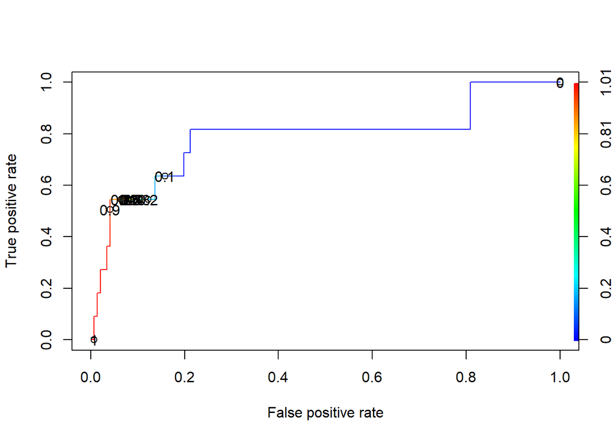

Fig. 4.1: Receiver operating characteristic (ROC) curve for baseline logistic model fit.

### 4.3.3 Threshold Tuning

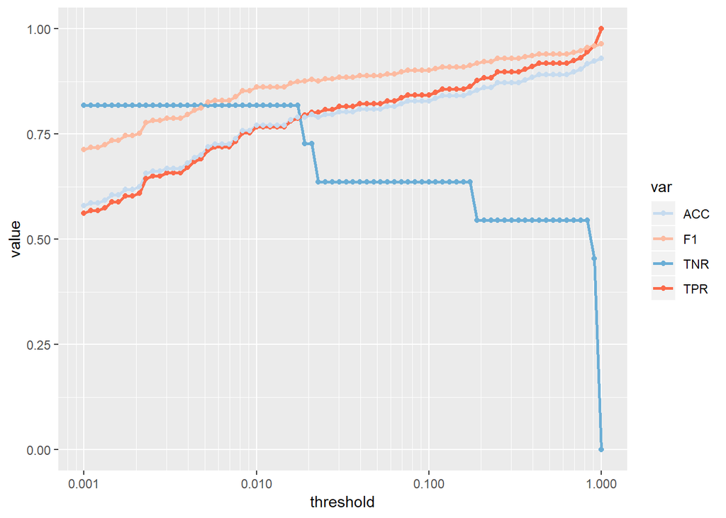

Fig. 4.2: TPR, TNR, accuracy and F1 score vs. threshold.

Fig. 4.2 plots the model performance versus threshold. Based on the criteria for high TNR and accuracy, the crossover point is chosen as the optimum threshold. Setting the threshold to 0.0174 increases TNR to 0.8182, but decreases accuracy to 0.7898 and TPR to 0.7877. F1 score = 0.8745.

```
## Confusion Matrix and Statistics
##
##           Reference
## Prediction   0   1
##          0 115   2
##          1  31   9
##
##                Accuracy : 0.7898
##                  95% CI : (0.7177, 0.8507)
##     No Information Rate : 0.9299
##     P-Value [Acc > NIR] : 1
##
##                   Kappa : 0.273
##  Mcnemar's Test P-Value : 1.093e-06
##
##             Sensitivity : 0.7877
##             Specificity : 0.8182
##          Pos Pred Value : 0.9829
##          Neg Pred Value : 0.2250
##              Prevalence : 0.9299
##          Detection Rate : 0.7325
##    Detection Prevalence : 0.7452
##       Balanced Accuracy : 0.8029
##
##        'Positive' Class : 0
##
```

### 4.3.4 Test

Test data results below show accuracy = 0.859, TPR = 0.863 and TNR = 0.8. F1 score = 0.9197.

```
## Confusion Matrix and Statistics
##
##           Reference
## Prediction  0  1
##          0 63  1
##          1 10  4
##
##                Accuracy : 0.859
##                  95% CI : (0.7617, 0.9274)
##     No Information Rate : 0.9359
##     P-Value [Acc > NIR] : 0.99604
##
##                   Kappa : 0.3607
##  Mcnemar's Test P-Value : 0.01586
##
##             Sensitivity : 0.8630
##             Specificity : 0.8000
##          Pos Pred Value : 0.9844
##          Neg Pred Value : 0.2857
##              Prevalence : 0.9359
##          Detection Rate : 0.8077
##    Detection Prevalence : 0.8205
##       Balanced Accuracy : 0.8315
##
##        'Positive' Class : 0
##
```

### 4.3.5 Summary

Table 4.2: Logistic model summary.

| Model | Stage | TPR | TNR | Accuracy | F1-Score |
| --- | --- | --- | --- | --- | --- |
| logistic | train | 0.9992 | 0.8977 | 0.9925 | 0.9960 |
| logistic | tune | 0.7877 | 0.8182 | 0.7898 | 0.8745 |
| logistic | test | 0.8630 | 0.8000 | 0.8590 | 0.9197 |

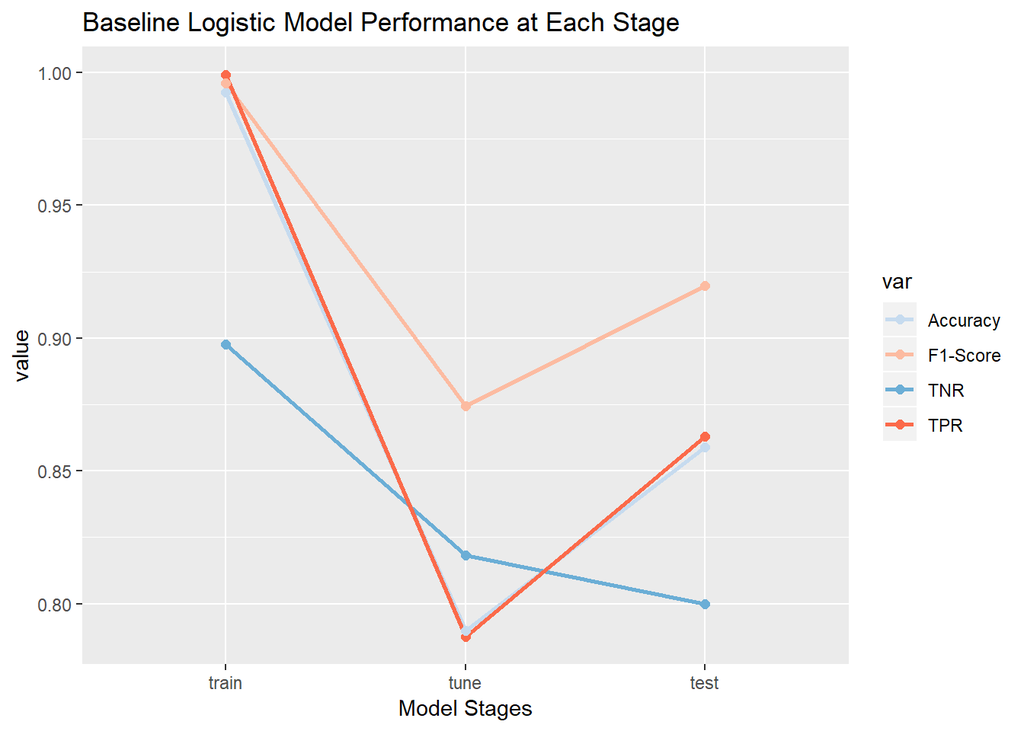

Fig. 4.3: TPR, TNR, accuracy and F1 score vs. model fit stage

## 4.4 Iterative Logistic Regression

### 4.4.1 Training

In the original logistic fit many coefficients showed very little significance, meaning their significance values were > 0.05. In the following fitting approach the logistic regression is performed iteratively with the least significant variable removed after each iteration. This assures that only the most significant features remain. Please refer to Appendix B for model output details. This approach shows a significant improvement in AIC score of 515. The accuracy = 0.9234, F1 score = 0.9601 and TPR = 0.9855 are also very good, but TNR = 0.0455 has dropped significantly compared with the base model. Confusion matrix results and a plot of most to least significant model features are shown below.

```
## Confusion Matrix and Statistics
##
##           Reference
## Prediction    0    1
##          0 1226   84
##          1   18    4
##
##                Accuracy : 0.9234
##                  95% CI : (0.9078, 0.9371)
##     No Information Rate : 0.9339
##     P-Value [Acc > NIR] : 0.9426
##
##                   Kappa : 0.0476
##  Mcnemar's Test P-Value : 1.227e-10
##
##             Sensitivity : 0.98553
##             Specificity : 0.04545
##          Pos Pred Value : 0.93588
##          Neg Pred Value : 0.18182
##              Prevalence : 0.93393
##          Detection Rate : 0.92042
##    Detection Prevalence : 0.98348
##       Balanced Accuracy : 0.51549
##
##        'Positive' Class : 0
##
```

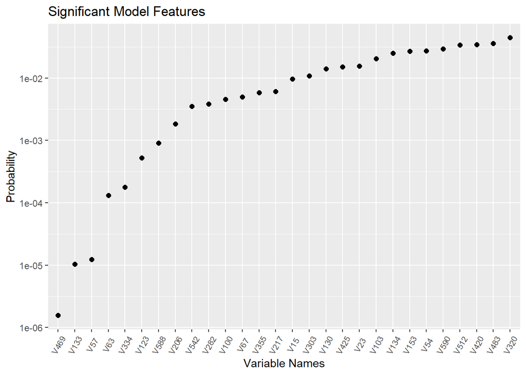

```
## Confusion Matrix and Statistics
##
##           Reference
## Prediction   0   1
##          0 144   8
##          1   2   3
##
##                Accuracy : 0.9363
##                  95% CI : (0.886, 0.969)
##     No Information Rate : 0.9299
##     P-Value [Acc > NIR] : 0.4555
##
##                   Kappa : 0.3464
##  Mcnemar's Test P-Value : 0.1138
##
##             Sensitivity : 0.9863
##             Specificity : 0.2727
##          Pos Pred Value : 0.9474
##          Neg Pred Value : 0.6000
##              Prevalence : 0.9299
##          Detection Rate : 0.9172
##    Detection Prevalence : 0.9682
##       Balanced Accuracy : 0.6295
##
##        'Positive' Class : 0
##
```

### 4.4.2 ROC Analysis

For this model AUC = 0.9066. The ROC curve is plotted below.

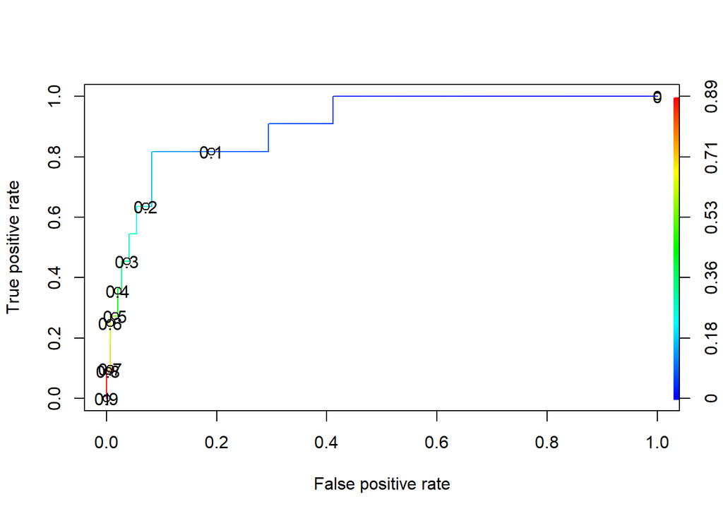

Fig. 4.5: Receiver operating characteristic (ROC) curve for baseline iterative logistic model fit.